# Practical Machine Learning

Prediction Assignment Writeup

Costas Fotopoulos

August 11, 2019

## 1. Introduction

Using devices such as Jawbone Up, Nike FuelBand, and Fitbit it is now possible to collect a large amount of data about personal activity relatively inexpensively. These type of devices are part of the quantified self movement – a group of enthusiasts who take measurements about themselves regularly to improve their health, to find patterns in their behavior, or because they are tech geeks. One thing that people regularly do is quantify how much of a particular activity they do, but they rarely quantify how well they do it. In this project, your goal will be to use data from accelerometers on the belt, forearm, arm, and dumbell of 6 participants. They were asked to perform barbell lifts correctly and incorrectly in 5 different ways. More information is available from the website here: http://web.archive.org/web/20161224072740/http:/groupware.les.inf.puc-rio.br/har (see the section on the Weight Lifting Exercise Dataset).

## 2. Data loading and cleaning

### 2.1 Data

The training data for this project are available here:

pml-training.csv

The test data are available here:

pml-testing.csv

### 2.2 Libraries

```r
library(caret)
library(rpart)
library(rpart.plot)
library(rattle)
library(randomForest)
library(corrplot)
library(gbm)
set.seed(12345)
```

### 2.3 Data loading

The next step is loading the dataset from the URL provided above.

```r
trainDataURL <- "https://d396qusza40orc.cloudfront.net/predmachlearn/pml-training.csv"
testDataURL <- "https://d396qusza40orc.cloudfront.net/predmachlearn/pml-testing.csv"

trainRowData <- read.csv(url(trainDataURL), header = TRUE)
testRowData <- read.csv(url(testDataURL), header = TRUE)
```

### 2.4 Partitioning data

The training dataset is then partinioned in 2 to create a Training set (70% of the data) for the modeling process and a Test set (with the remaining 30%) for the validations.

```r
inTrain <- createDataPartition(trainRowData$classe, p = 0.7, list = FALSE)
trainData <- trainRowData[inTrain,]
testData <- trainRowData[-inTrain,]
dim(trainData)
```

```
## [1] 13737   160
```

```r
dim(testData)
```

```
## [1] 5885  160
```

Both datasets have 160 variables.

### 2.5 Cleaning data

The Near Zero Variance (NZV) variables can be removed with the cleaning procedures below:

```r
NZV <- nearZeroVar(trainData)
trainData <- trainData[, -NZV]
testData <- testData[, -NZV]
```

Variables that are mostly NA also removed:

```r
NAs <- sapply(trainData, function(x) mean(is.na(x))) > 0.95
trainData <- trainData[, NAs == FALSE]
testData <- testData[, NAs == FALSE]
```

Also remove identification only variables (columns 1 to 5):

```r
trainData <- trainData[, -(1:5)]
testData <- testData[, -(1:5)]
dim(trainData)
```

```
## [1] 13737    54
```

```r
dim(testData)
```

```
## [1] 5885   54
```

With the cleaning process above, the number of variables for the analysis has been reduced to 54 only.

## 3. Correlation Analysis

A correlation among variables is analysed before proceeding to the modeling procedures.

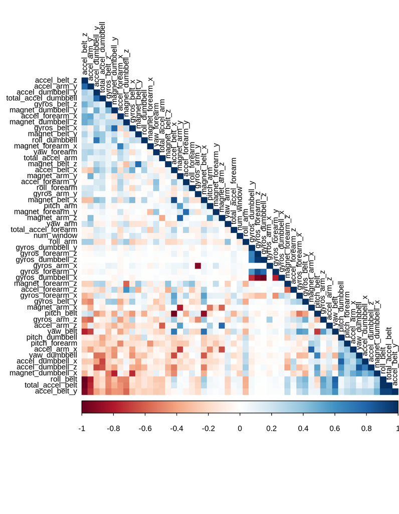

```r
corMatrix <- cor(trainData[,-54])
corrplot(corMatrix, order = "FPC", method = "color",
         type = "lower", tl.cex = 0.8, tl.col = rgb(0,0,0))
```

The highly correlated variables are shown in dark colors. The correlations are quite few.

## 4. Prediction model building

Three methods will be applied to model the regressions (in the Train dataset) and the best one (with higher accuracy when applied to the Test dataset) will be used for the quiz predictions. The methods are:

1. Radom Forest
2. Decision Tree
3. Generalized Boosted Model

### 4.1 Radom Forest

#### Model fit

```r
set.seed(12345)
ctrlRF <- trainControl(method = "cv", number = 3, verboseIter = FALSE)
modFitRF <- train(classe ~ ., data = trainData, method = "rf",
                  trControl = ctrlRF)
modFitRF$finalModel
```

```
##
## Call:
##  randomForest(x = x, y = y, mtry = param$mtry)
##                Type of random forest: classification
##                      Number of trees: 500
## No. of variables tried at each split: 27
##
##         OOB estimate of  error rate: 0.2%
## Confusion matrix:
##      A    B    C    D    E  class.error
## A 3904    1    0    0    1 0.0005120328
## B    6 2649    2    1    0 0.0033860045
## C    0    4 2391    1    0 0.0020868114
## D    0    0    7 2245    0 0.0031083481
## E    0    0    0    5 2520 0.0019801980
```

#### Prediction on Test dataset and Accuracy

```r
predictRF <- predict(modFitRF, newdata = testData)
confMatRF <- confusionMatrix(predictRF, testData$classe)
round(confMatRF$overall['Accuracy'], 4)
```

```
## Accuracy
##   0.9964
```

For this model **accuracy** is about **0.9964**

### 4.2 Decision Trees

#### Model fit

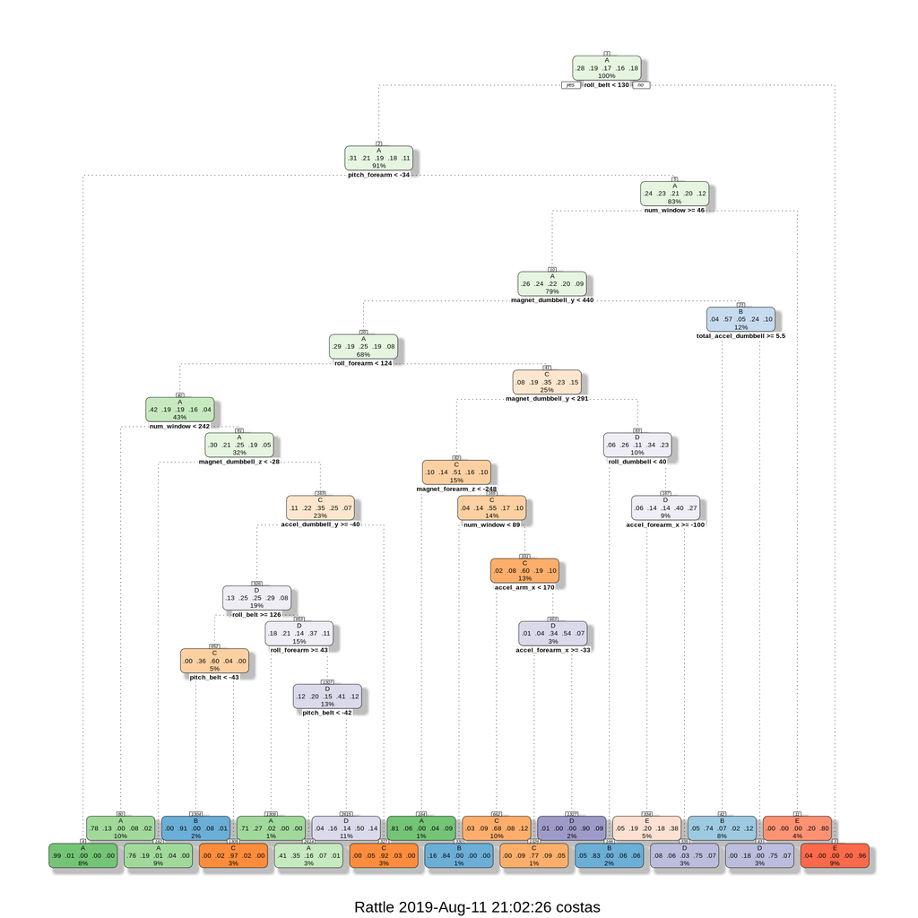

```r
set.seed(12345)
modFitDT <- rpart(classe ~ ., data = trainData, method = "class")
fancyRpartPlot(modFitDT)
```

#### Prediction on Test dataset and Accuracy

```r
predictDT <- predict(modFitDT, newdata =testData, type = "class")
confMatDT <- confusionMatrix(predictDT, testData$classe)
round(confMatDT$overall['Accuracy'], 4)
```

```
## Accuracy
##   0.7368
```

For this model **accuracy** is about **0.7368**

### 4.3 Generalized Boosted Model

#### Model fit

```r
set.seed(12345)
ctrlGBM <- trainControl(method = "repeatedcv", number = 5, repeats = 1)
modFitGBM <- train(classe ~ ., data = trainData, method = "gbm",
                   trControl = ctrlGBM, verbose = FALSE)
modFitGBM$finalModel
```

```
## A gradient boosted model with multinomial loss function.
## 150 iterations were performed.
## There were 53 predictors of which 53 had non-zero influence.
```

#### Prediction on Test dataset and Accuracy

```r
predictGBM <- predict(modFitGBM, newdata = testData)
confMatGBM <- confusionMatrix(predictGBM, testData$classe)
round(confMatGBM$overall['Accuracy'], 4)
```

```
## Accuracy
##   0.9857
```

For this model **accuracy** is about **0.9857**

## 5. Applying best model to the test data

The best model is Radom Forest (accuracy 0.9964) and will be applied to predict the 20 quiz results (testing dataset) as shown below:

```r
predictTest <- predict(modFitRF, newdata=testRowData)
predictTest
```

```
##  [1] B A B A A E D B A A B C B A E E A B B B
## Levels: A B C D E
```